# Natural Language Processing and Cognitive Computing

## Final Project Data Science

#### Submitted by: Sakshi Shende

## Prompt

In March of 2023, Goldman Sachs published a report, indicating that ~25% of the tasks in US and Europe can be automated using AI. However, as you can see in this visualization, not all industries will be affected equally. According to the report, certain jobs, like office tasks, legal, architecture and social sciences have a potential for 30%+ automation, while positions like construction, installation and building maintenance are going to be largely unaffected.

You can also see supporting evidence in the Facebook Research paperLinks to an external site., which highlights Moravec’s paradox, the thesis that the hardest problems in AI involve sensorimotor skills, not abstract thought or reasoning, which coincide with Goldman Sachs predictions.

While both of these papers are very impressive, they also heavily influenced by the recent advances in Large Language Models (LLMs). For this final project I have prepared a collection of ~200K news articles (about 900 MB) articles on our favorite topics: Data Science, Machine Learning and Artificial Intelligence, and I want you to identify what industries and job lines are going to be most impacted by the AI over the next several years, based on the information you can disseminate from this text corpus.

The objective of your final project is to identify what types of tasks and jobs are most likely to see the biggest impact from AI by extracting meaningful insights from unstructured text. Your goal is to provide actionable recommendations on what can be done with AI to automate the jobs and / or improve employee productivity. Please pay attention to the introduction of novel technologies and algorithms, such as AI for image generation and Conversational AI, as they represent the entire paradigm shift in adoption of AI technologies and data science in general.

```python
#!pip install pandarallel
#!pip install nltk
```

```python
import pandas as pd
import numpy as np
import matplotlib.pyplot as plt
import seaborn as sns
import re
import string
import nltk
nltk.download('all')
from pandarallel import pandarallel
from google.cloud import storage

pd.set_option('display.max_rows', 100)
pd.set_option('display.max_columns', None)
pd.set_option('display.max_colwidth', 500)
```

```python
import multiprocessing
num_processors = multiprocessing.cpu_count()
print(f'Available CPUs: {num_processors}')
```

```
Available CPUs: 96
```

```python
from pandarallel import pandarallel
pandarallel.initialize(progress_bar=False, nb_workers=num_processors-1, use_memory_fs=False)
```

```
INFO: Pandarallel will run on 95 workers.
INFO: Pandarallel will use standard multiprocessing data transfer (pipe) to transfer data between the main process and workers.
```

```python
%%time
df_news_final_project = pd.read_parquet('https://storage.googleapis.com/msca-bdp-data-open/news_final_project/news_final_project.parquet', engine='pyarrow')
df_news_final_project.shape
```

```
CPU times: user 6.8 s, sys: 4.87 s, total: 11.7 s
Wall time: 36.2 s
```

```
(199208, 5)
```

```python
df_news_final_project.head()
```

|  | url | date | language | title | text |
| --- | --- | --- | --- | --- | --- |
| 0 | http://newsparliament.com/2020/02/27/children-with-autism-saw-their-learning-and-social-skills-boosted-after-playing-with-this-ai-robot/ | 2020-02-27 | en | Children With Autism Saw Their Learning and Social Skills Boosted After Playing With This AI Robot – News Parliament | \nChildren With Autism Saw Their Learning and Social Skills Boosted After Playing With This AI Robot – News Parliament\n \n\nSkip to content\n\t\t\tThursday, February 27, 2020\t\t\n\nLatest:\n\n\nMans… |
| 1 | http://thedailycougar.com/2021/11/24/college-of-technology-to-launch-ai-retail-lab/ | 2021-11-24 | en | College of Technology to launch AI Retail Lab - The Cougar | \nCollege of Technology to launch AI Retail Lab - The Cougar\nside bar\n\n\nHome\nCoronavirus\nNews\n\nAcademics & Research\nActivities & Organizations\nAdministration\nAlumni\nState\nStudent Governme… |
| 2 | http://www.desototimes.com/news/child-actor-claude-jarman-jr-looks-back-on-his-movie-career-during-the-golden-days/article_0b310fae-e767-11ec-982e-a380305dda2f.html | 2022-06-09 | en | Child actor Claude Jarman Jr. looks back on his movie career during the “Golden Days” of Hollywood \| News \| desototimes.com | \nChild actor Claude Jarman Jr. looks back on his movie career during the “Golden Days” of Hollywood \| News \| desototimes.com\nSkip to main content\n\nYou have permission to edit this article.\n\n E… |
| 3 | http://www.mysmartrend.com/news-briefs/technical-analysis/cr-bard-inc-has-returned-489-smartrend-recommendation-bcr-2 | 2020-04-17 | en | Cr Bard Inc Has Returned 48.9% Since SmarTrend Recommendation (BCR) \| Comtex SmarTrend | \n\nCr Bard Inc Has Returned 48.9% Since SmarTrend Recommendation (BCR) \| Comtex SmarTrend\n \nOWL LOGIN / \n ADVISOR LOGIN\n\nHome\nAdvantages\nProducts\n\nNews &amp Analysis\n\n\nResources\nTestimo… |
| 4 | http://www.peripherals.consumerelectronicsnet.com/multicoreware-inc-becomes-cevas-trusted-partner-for-imaging-computer-vision/ | 2021-02-25 | en | MulticoreWare Inc. Becomes CEVA’s Trusted Partner for Imaging & Computer Vision – Consumer Electronics Net | \n\nMulticoreWare Inc. Becomes CEVA’s Trusted Partner for Imaging & Computer Vision – Consumer Electronics Net\n\n \nSkip to content\n\nConsumer Electronics Net\n\nPrimary Menu\n\nConsumer Electronics… |

```python
# Extract articles in english language
news_eng = df_news_final_project[df_news_final_project['language'] == 'en']
news_eng.sample(n = 5, random_state = 42)
```

|  | url | date | language | title | text |
| --- | --- | --- | --- | --- | --- |
| 135881 | https://www.kplctv.com/prnewswire/2022/06/08/qyseas-innovative-ai-vision-lock-platform-sets-new-standard-underwater-drone-explorations/ | 2022-06-08 | en | QYSEA's Innovative AI Vision Lock Platform Sets a New Standard for Underwater Drone Explorations | QYSEA's Innovative AI Vision Lock Platform Sets a New Standard for Underwater Drone Explorations\n\nSkip to content50/50 ThursdaysConnectionsCoca-Cola Restaurant GuideThe Pledge of AllegianceLivestrea… |
| 87337 | https://www.nasdaq.com/articles/paypal-is-using-ai-to-supercharge-profits | 2023-05-25 | en | PayPal Is Using AI to Supercharge Profits \| Nasdaq | \nPayPal Is Using AI to Supercharge Profits \| Nasdaq\n\n \nSkip to main content\nNasdaq+\nMarket Recap\n\nMarket Activity\n\nMarket Activity\n->\n\nStocks\n\n\nOptions\n\n\nETFs\n\n\nMutual Funds\n\n… |
| 117475 | https://womenlovetech.com/professor-cath-ellis-on-chatgpt-and-the-controversy-surrounding-student-cheating/ | 2023-02-12 | en | Professor Cath Ellis: ChatGPT And The Controversy Surrounding Student Cheating - Women Love Tech | \n \nProfessor Cath Ellis: ChatGPT And The Controversy Surrounding Student Cheating - Women Love Tech\nProfessor Cath Ellis: ChatGPT And Student Cheating\nProfessor Cath Ellis: ChatGPT And Student Che… |
| 54075 | https://www.cnet.com/news/social-media/facebook-parent-meta-wants-to-show-its-still-a-big-contender-in-ai-race/ | 2023-02-24 | en | Facebook Parent Meta Wants to Show It's Still a Big Contender in AI Race - CNET | \n\n\nFacebook Parent Meta Wants to Show It's Still a Big Contender in AI Race - CNET\n\n\n X Russia, Ukraine and Cyberwar'Cocaine Bear' ReviewAir Fryer Recall5 Exercises for Mental HealthiOS 16 Trick… |
| 66928 | https://marketmirror24.com/2021/03/23/artificial-intelligence-market-is-expected-to-grow-at-a-cagr-of-36-68-over-the-forecasted-period-of-2017-2025/ | 2021-03-23 | en | Artificial Intelligence Market is Expected to Grow at a CAGR of 36.68% Over the Forecasted Period of 2017-2025 – Market Mirror | \nArtificial Intelligence Market is Expected to Grow at a CAGR of 36.68% Over the Forecasted Period of 2017-2025 – Market Mirror\nSkip to content\nAleje Jerozolimskie 65/79, 00-697 Warsaw, Poland\n[em… |

# News Source

```python
news_eng['url'].head(3)
```

```
0                                http://newsparliament.com/2020/02/27/children-with-autism-saw-their-learning-and-social-skills-boosted-after-playing-with-this-ai-robot/
1                                                                                     http://thedailycougar.com/2021/11/24/college-of-technology-to-launch-ai-retail-lab/
2    http://www.desototimes.com/news/child-actor-claude-jarman-jr-looks-back-on-his-movie-career-during-the-golden-days/article_0b310fae-e767-11ec-982e-a380305dda2f.html
Name: url, dtype: object
```

```python
from urllib.parse import urlparse

# Define a function to extract domain from a URL
def extract_domain(url):
    parsed_url = urlparse(url)
    domain = parsed_url.netloc
    if domain.startswith("www."):
        domain = domain[4:]
    parts = domain.split('.')
    cleaned_domain = parts[0] if len(parts) > 1 else domain
    return cleaned_domain

# Apply the function to the 'url' column and create a new 'domain' column
news_eng['domain'] = news_eng['url'].parallel_apply(extract_domain)
```

```python
news_eng[['url', 'domain']].sample(n = 5)
```

|  | url | domain |
| --- | --- | --- |
| 112919 | https://www.nbc11news.com/prnewswire/2021/10/13/survey-finds-poor-customer-service-affects-consumer-brand-loyalty-conversational-ai-may-help-them-stay/ | nbc11news |
| 177863 | https://www.ksla.com/prnewswire/2023/06/07/okx-brings-web3-ai-life-tribeca-festival-with-interactive-nft-lab-spring-studios-nyc/ | ksla |
| 48407 | https://www.nbc15.com/prnewswire/2023/03/30/embrace-pet-insurance-launches-modern-approach-claims-processing-with-proprietary-ai-solution/ | nbc15 |
| 199043 | https://www.todayonline.com/world/taiwan-may-export-orders-fall-9th-month-find-comfort-rising-ai-demand-2196846 | todayonline |
| 78239 | https://www.nbc11news.com/prnewswire/2023/02/03/rockefeller-foundation-celebrates-continued-investment-philanthropic-impact-atlanta/ | nbc11news |

```python
news_eng['domain'].value_counts().head(15)
```

```
prnewswire           4345
newsbreak            2789
einpresswire         2538
forbes               1929
venturebeat          1885
wfmz                 1691
producthunt          1461
globenewswire        1246
finanznachrichten    1215
finance              1212
nasdaq               1139
mccourier            1073
exbulletin           1062
dailymail            1048
murphyshockeylaw     1021
Name: domain, dtype: int64
```

```python
# Get the top 10 domains by value counts
top_10_domains = news_eng['domain'].value_counts().head(15).index.tolist()

# Filter the DataFrame for the top 10 domains
top_10_news_eng = news_eng[news_eng['domain'].isin(top_10_domains)]
```

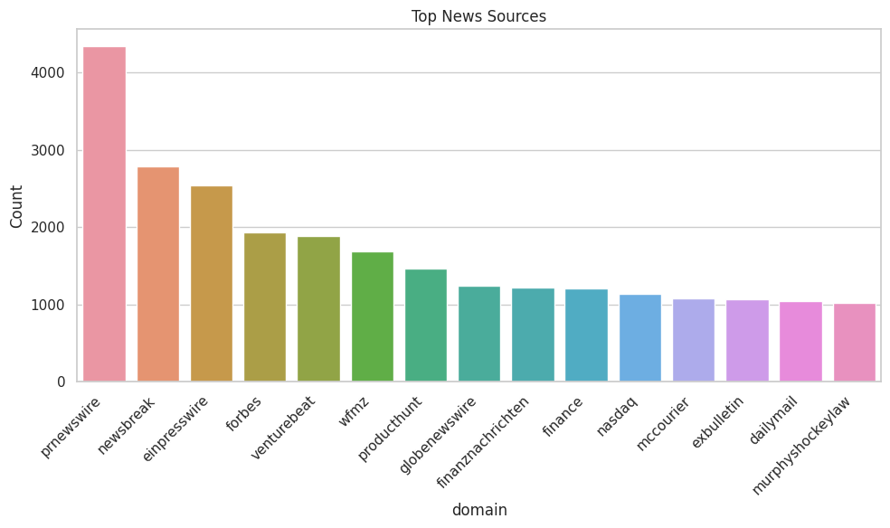

```python
# Plot using Seaborn
plt.figure(figsize=(10, 6))
sns.set(style="whitegrid")
ax = sns.countplot(x="domain", data=top_10_news_eng, order=top_10_domains, orient="v")
ax.set_xticklabels(ax.get_xticklabels(), rotation=45, ha="right")
plt.ylabel("Count")
plt.title("Top News Sources")
plt.tight_layout()
plt.show()
```

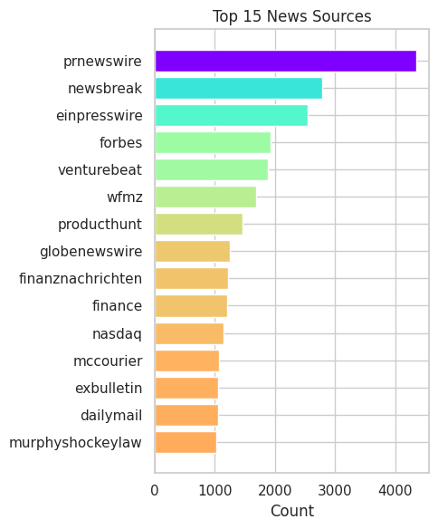

```python
top_domains = news_eng['domain'].value_counts().head(15)
top_domains = top_domains.sort_values()  # Sort in ascending order

plt.figure(figsize=(5, 6))
colors = plt.cm.rainbow_r(top_domains.values / float(max(top_domains.values)))  # Use rainbow colormap in reverse
plt.barh(top_domains.index, top_domains.values, color=colors)
plt.xlabel("Count")
plt.title("Top 15 News Sources")
plt.tight_layout()
plt.show()
```

```python
# Create a dictionary to map news sources to their categories
source_to_category = {
    "prnewswire": "Press Release",
    "newsbreak": "Local News",
    "einpresswire": "Press Release",
    "forbes": "Business",
    "venturebeat": "Technology",
    "wfmz": "Local News",
    "producthunt": "Technology",
    "globenewswire": "Press Release",
    "finanznachrichten": "Finance",
    "finance": "Finance",
    "nasdaq": "Finance",
    "mccourier": "Local News",
    "exbulletin": "News Portal",
    "dailymail": "News Portal",
    "murphyshockeylaw": "Sports"
}

# Map news sources to their categories
top_10_news_eng['category'] = top_10_news_eng['source'].map(source_to_category)
top_10_news_eng
```

[output not shown]

```python
news_sources['category']
```

```
0     Press Release
1        Local News
2     Press Release
3          Business
4        Technology
5        Local News
6        Technology
7     Press Release
8           Finance
9           Finance
10          Finance
11       Local News
12      News Portal
13      News Portal
14           Sports
Name: category, dtype: object
```

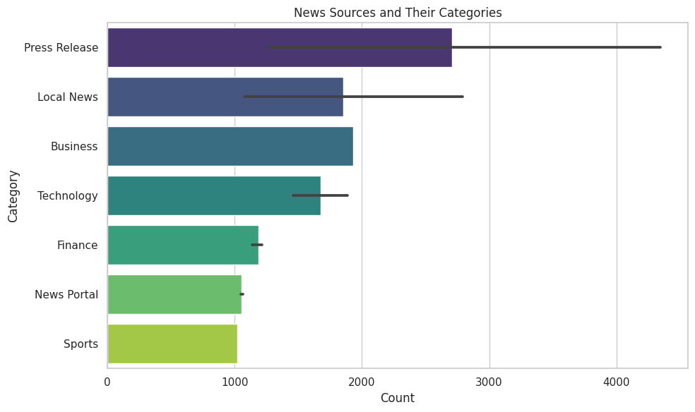

```python
plt.figure(figsize=(10, 6))
sns.barplot(x='count', y='category', data=news_sources, palette='viridis')
plt.xlabel("Count")
plt.ylabel("Category")
plt.title("News Sources and Their Categories")
plt.tight_layout()
plt.show()
```

```python
# remove irrelevant columns
news_eng_rel = news_eng
news_eng_rel.sample(n = 5, random_state = 42)
```

|  | url | date | language | title | text |
| --- | --- | --- | --- | --- | --- |
| 135881 | https://www.kplctv.com/prnewswire/2022/06/08/qyseas-innovative-ai-vision-lock-platform-sets-new-standard-underwater-drone-explorations/ | 2022-06-08 | en | QYSEA's Innovative AI Vision Lock Platform Sets a New Standard for Underwater Drone Explorations | QYSEA's Innovative AI Vision Lock Platform Sets a New Standard for Underwater Drone Explorations\n\nSkip to content50/50 ThursdaysConnectionsCoca-Cola Restaurant GuideThe Pledge of AllegianceLivestrea… |
| 87337 | https://www.nasdaq.com/articles/paypal-is-using-ai-to-supercharge-profits | 2023-05-25 | en | PayPal Is Using AI to Supercharge Profits \| Nasdaq | \nPayPal Is Using AI to Supercharge Profits \| Nasdaq\n\n \nSkip to main content\nNasdaq+\nMarket Recap\n\nMarket Activity\n\nMarket Activity\n->\n\nStocks\n\n\nOptions\n\n\nETFs\n\n\nMutual Funds\n\n… |
| 117475 | https://womenlovetech.com/professor-cath-ellis-on-chatgpt-and-the-controversy-surrounding-student-cheating/ | 2023-02-12 | en | Professor Cath Ellis: ChatGPT And The Controversy Surrounding Student Cheating - Women Love Tech | \n \nProfessor Cath Ellis: ChatGPT And The Controversy Surrounding Student Cheating - Women Love Tech\nProfessor Cath Ellis: ChatGPT And Student Cheating\nProfessor Cath Ellis: ChatGPT And Student Che… |
| 54075 | https://www.cnet.com/news/social-media/facebook-parent-meta-wants-to-show-its-still-a-big-contender-in-ai-race/ | 2023-02-24 | en | Facebook Parent Meta Wants to Show It's Still a Big Contender in AI Race - CNET | \n\n\nFacebook Parent Meta Wants to Show It's Still a Big Contender in AI Race - CNET\n\n\n X Russia, Ukraine and Cyberwar'Cocaine Bear' ReviewAir Fryer Recall5 Exercises for Mental HealthiOS 16 Trick… |
| 66928 | https://marketmirror24.com/2021/03/23/artificial-intelligence-market-is-expected-to-grow-at-a-cagr-of-36-68-over-the-forecasted-period-of-2017-2025/ | 2021-03-23 | en | Artificial Intelligence Market is Expected to Grow at a CAGR of 36.68% Over the Forecasted Period of 2017-2025 – Market Mirror | \nArtificial Intelligence Market is Expected to Grow at a CAGR of 36.68% Over the Forecasted Period of 2017-2025 – Market Mirror\nSkip to content\nAleje Jerozolimskie 65/79, 00-697 Warsaw, Poland\n[em… |

```python
news_eng_rel.isna().sum()
```

```
url         0
date        0
language    0
title       0
text        0
dtype: int64
```

```python
news_eng_rel.describe()
```

|  | url | date | language | title | text |
| --- | --- | --- | --- | --- | --- |
| count | 199208 | 199208 | 199208 | 199208 | 199208 |
| unique | 199208 | 1291 | 1 | 141632 | 198041 |
| top | http://newsparliament.com/2020/02/27/children-with-autism-saw-their-learning-and-social-skills-boosted-after-playing-with-this-ai-robot/ | 2023-05-18 | en | Virtus Artificial Intelligence &amp; Technology Opportunities Fund Discloses Sources of Distribution - Section 19(a) Notice | Accelerate the Development of AI Applications \| Scale AI |
| freq | 1 | 1066 | 199208 | 193 | 13 |

```python
news_eng_rel.dtypes
```

[output not shown]

```python
# convert to appropriate datatypes
news_eng_rel['date'] = pd.to_datetime(news_eng_rel['date'])
news_eng_rel.dtypes
```

[output not shown]

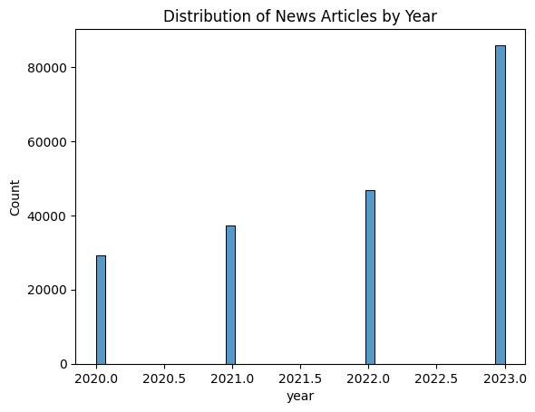

```python
# Extract year
news_eng_rel['year'] = news_eng_rel['date'].dt.year

# Plot a histogram to visualize the distribution of news articles over different years.
sns.histplot(data=news_eng_rel, x='year')
plt.title('Distribution of News Articles by Year')
plt.show()
```

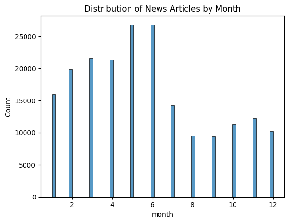

```python
# Extract month
news_eng_rel['month'] = news_eng_rel['date'].dt.month

# Plot a histogram to visualize the distribution of news articles over different month.
sns.histplot(data=news_eng_rel, x='month')
plt.title('Distribution of News Articles by Month')
plt.show()
```

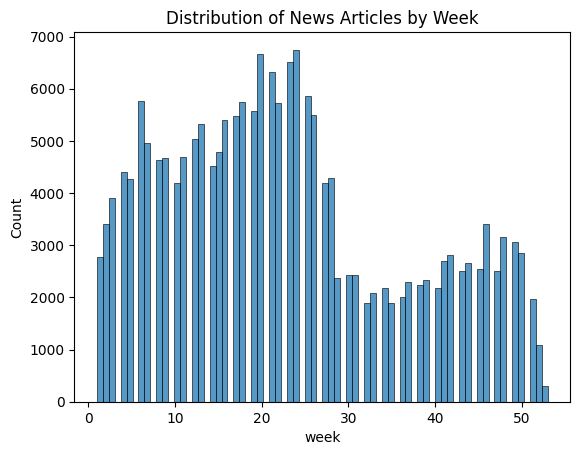

```python
# Extract week
news_eng_rel['week'] = news_eng_rel['date'].dt.week

# Plot a histogram to visualize the distribution of news articles over week.
sns.histplot(data=news_eng_rel, x='week')
plt.title('Distribution of News Articles by Week')
plt.show()
```

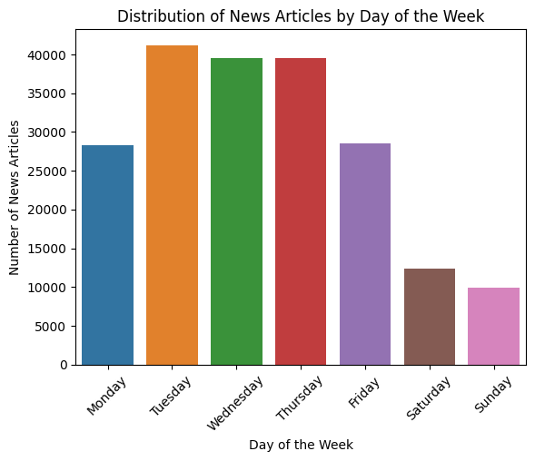

```python
# Extract day of the week and map to day names
news_eng_rel['day_of_week'] = news_eng_rel['date'].dt.dayofweek
news_eng_rel['day_of_week_name'] = news_eng_rel['date'].dt.day_name()

# Define the desired order of the days of the week
desired_order = ['Monday', 'Tuesday', 'Wednesday', 'Thursday', 'Friday', 'Saturday', 'Sunday']

# Plot a count plot to visualize the distribution of news articles over the day of the week.
sns.countplot(data=news_eng_rel, x='day_of_week_name', order=desired_order)
plt.title('Distribution of News Articles by Day of the Week')
plt.xlabel('Day of the Week')
plt.ylabel('Number of News Articles')
plt.xticks(rotation=45)
plt.show()
```

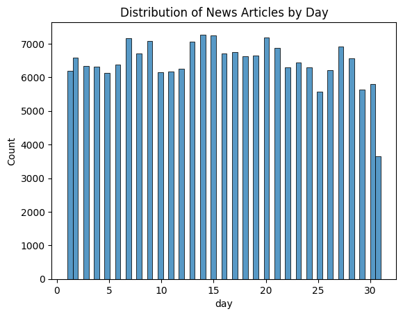

```python
# Extract day
news_eng_rel['day'] = news_eng_rel['date'].dt.day

# Plot a histogram to visualize the distribution of news articles over day.
sns.histplot(data=news_eng_rel, x='day')
plt.title('Distribution of News Articles by Day')
plt.show()
```

```python
news_eng_rel[['title']].iloc[199206]
```

```
title    This World | Bard vs Bing: Google and Microsoft fight it out for AI dominance | Zee News
Name: 199206, dtype: object
```

```python
news_eng_rel[['text']].iloc[199206]
```

```
text    This World | Bard vs Bing: Google and Microsoft fight it out for AI dominance | Zee Newsहिन्दीEnglishमराठीবাংলাதமிழ்മലയാളംગુજરાતીతెలుగుಕನ್ನಡBusinessTechWorldHealthNEWSVIDEOSPHOTOSWeb StoriesLogoutSign InLogoutGOHomeLive TVAdani Saga Latest NewsIndiaAhmedabadBengaluruChennaiHyderabadKolkataMu…
Name: 199206, dtype: object
```

```python
pd.set_option('display.max_colwidth', 500)
news_eng_rel[['title', 'text']].sample(n = 5, random_state = 42)
```

|  | title | text |
| --- | --- | --- |
| 135881 | QYSEA's Innovative AI Vision Lock Platform Sets a New Standard for Underwater Drone Explorations | QYSEA's Innovative AI Vision Lock Platform Sets a New Standard for Underwater Drone Explorations\n\nSkip to content50/50 ThursdaysConnectionsCoca-Cola Restaurant GuideThe Pledge of AllegianceLivestrea… |
| 87337 | PayPal Is Using AI to Supercharge Profits \| Nasdaq | \nPayPal Is Using AI to Supercharge Profits \| Nasdaq\n\n \nSkip to main content\nNasdaq+\nMarket Recap\n\nMarket Activity\n\nMarket Activity\n->\n\nStocks\n\n\nOptions\n\n\nETFs\n\n\nMutual Funds\n\n… |
| 117475 | Professor Cath Ellis: ChatGPT And The Controversy Surrounding Student Cheating - Women Love Tech | \n \nProfessor Cath Ellis: ChatGPT And The Controversy Surrounding Student Cheating - Women Love Tech\nProfessor Cath Ellis: ChatGPT And Student Cheating\nProfessor Cath Ellis: ChatGPT And Student Che… |
| 54075 | Facebook Parent Meta Wants to Show It's Still a Big Contender in AI Race - CNET | \n\n\nFacebook Parent Meta Wants to Show It's Still a Big Contender in AI Race - CNET\n\n\n X Russia, Ukraine and Cyberwar'Cocaine Bear' ReviewAir Fryer Recall5 Exercises for Mental HealthiOS 16 Trick… |
| 66928 | Artificial Intelligence Market is Expected to Grow at a CAGR of 36.68% Over the Forecasted Period of 2017-2025 – Market Mirror | \nArtificial Intelligence Market is Expected to Grow at a CAGR of 36.68% Over the Forecasted Period of 2017-2025 – Market Mirror\nSkip to content\nAleje Jerozolimskie 65/79, 00-697 Warsaw, Poland\n[em… |

We can see that the title is embedded with the text. Hence, for out analysis, we will only take text into consideration.

```python
# Function to clean news articles
def clean_text(text):
    # Use regex pattern to find HTML remnants (tags or elements within angle brackets)
    html_remnants_pattern = re.compile(r'<[^>]+>')

    # Remove HTML remnants by replacing them with an empty string
    cleaned_text = html_remnants_pattern.sub('', text)

    # Remove any extra spaces and white spaces resulting from removing the HTML remnants
    cleaned_text = re.sub(r'\s+', ' ', cleaned_text).strip()

    # Remove weblinks
    cleaned_text = re.sub(r'http\S+|www\S+', '', cleaned_text)

    # Remove email IDs
    cleaned_text = re.sub(r'\S+@\S+', '', cleaned_text)

    # Remove symbols and non-ASCII characters
    cleaned_text = re.sub(r'[^\x00-\x7F]', '', cleaned_text)

    # Remove newline characters and tab characters
    cleaned_text = re.sub(r'[\n\t]', ' ', cleaned_text)

    # Remove punctuations
    cleaned_text = cleaned_text.translate(str.maketrans('', '', string.punctuation))

    # Remove numbers
    cleaned_text = " ".join([word for word in cleaned_text.split() if not word.isnumeric()])

    # Remove stopwords
    stopwords = set(nltk.corpus.stopwords.words('english'))
    cleaned_text = " ".join([word for word in cleaned_text.split() if word not in stopwords])

    # Remove extra spaces and white spaces
    cleaned_text = re.sub(r'\s+', ' ', cleaned_text).strip()

    return cleaned_text
```

```python
%%time
pandarallel.initialize()

news_eng_rel['clean_title'] = news_eng_rel['title'].parallel_apply(lambda x : clean_text(x))
```

```
INFO: Pandarallel will run on 48 workers.
INFO: Pandarallel will use Memory file system to transfer data between the main process and workers.
CPU times: user 275 ms, sys: 4.17 s, total: 4.44 s
Wall time: 5.96 s
```

```python
%%time
pandarallel.initialize()

news_eng_rel['clean_text'] = news_eng_rel['text'].parallel_apply(lambda x : clean_text(x))
```

```
INFO: Pandarallel will run on 48 workers.
INFO: Pandarallel will use Memory file system to transfer data between the main process and workers.
CPU times: user 3.39 s, sys: 8.06 s, total: 11.4 s
Wall time: 30.3 s
```

```python
news_eng_rel[['text']].iloc[199206]
```

```
text    This World | Bard vs Bing: Google and Microsoft fight it out for AI dominance | Zee Newsहिन्दीEnglishमराठीবাংলাதமிழ்മലയാളംગુજરાતીతెలుగుಕನ್ನಡBusinessTechWorldHealthNEWSVIDEOSPHOTOSWeb StoriesLogoutSign InLogoutGOHomeLive TVAdani Saga Latest NewsIndiaAhmedabadBengaluruChennaiHyderabadKolkataMu…
Name: 199206, dtype: object
```

```python
news_eng_rel[['clean_text']].iloc[199206]
```

```
clean_text    This World Bard vs Bing Google Microsoft fight AI dominance Zee NewsEnglishBusinessTechWorldHealthNEWSVIDEOSPHOTOSWeb StoriesLogoutSign InLogoutGOHomeLive TVAdani Saga Latest NewsIndiaAhmedabadBengaluruChennaiHyderabadKolkataMumbaiPuneMY MONEYCricketEntertainmentHollywoodMusicBollywood…
Name: 199206, dtype: object
```

## Checking results after cleaning

```python
def find_html_remnants(text):
    # Use regex pattern to find HTML remnants (tags or elements within angle brackets)
    html_remnants = re.findall(r'<[^>]+>', text)
    if html_remnants:
        return html_remnants
    else:
        return pd.NA  # Returns 'nan' for missing values

# Apply the find_html_remnants function to the 'text' column
news_eng_rel['html_remnants'] = news_eng_rel['text'].parallel_apply(find_html_remnants)
news_eng_rel['clean_html_remnants'] = news_eng_rel['clean_text'].parallel_apply(find_html_remnants)
```

```python
sample_data = news_eng_rel[['text', 'html_remnants', 'clean_text', 'clean_html_remnants']]

# Filter rows where 'html_remnants' is not NaN
filtered_data = sample_data[sample_data['html_remnants'].notna()]
filtered_data.sample(n = 5, random_state = 42)
```

|  | text | html_remnants | clean_text | clean_html_remnants |
| --- | --- | --- | --- | --- |
| 76292 | \nAmid AI hype, tech companies are taking a step back from the metaverse : NPR\n\nAccessibility links \nSkip to main content\nKeyboard shortcuts for audio player\n\n Open Navigation Menu\n \nNPR Shop\… | [<iframe src="https://www.npr.org/player/embed/1167645442/1167645443" width="100%" height="290" frameborder="0" scrolling="no" title="NPR embedded audio player">] | Amid AI hype tech companies taking step back metaverse NPR Accessibility links Skip main content Keyboard shortcuts audio player Open Navigation Menu NPR Shop Close Navigation Menu Home News Expandcol… | <NA> |
| 73035 | Hot or not? Bizarre online chatroom uses AI to score your looks \| Daily Mail Online\n\n \n\n \nHome\n\nShowbiz\n\nFemail\n\nRoyals\n\nHealth\n\nScience\n\nSports\n\nPolitics\n\nU.K.\n\nMoney\n\nVideo… | [<!- - ad: https://mads.dailymail.co.uk/v8/us/sciencetech/none/article/other/mpu_factbox.html?id=mpu_factbox_1 - ->, <!- - ad: https://mads.dailymail.co.uk/v8/us/sciencetech/none/article/other/mpu_fac… | Hot Bizarre online chatroom uses AI score looks Daily Mail Online Home Showbiz Femail Royals Health Science Sports Politics UK Money Video Travel Shop Latest Headlines NASA Apple Twitter Games My Prof… | <NA> |
| 107644 | \nNext Up For AI Chatbots: It’s All About The APIs - SoylentNews\n\nStories\n\nSlash Boxes\n\nComments\n\nSoylentNews\n\nSoylentNews is people\n\t\t\tNavigation\n\t\t\n\nAbout\n\n\nFAQ\n\n\nJournals\n… | [<199705101952.MAA00756@wall.org>] | Next Up For AI Chatbots Its All About The APIs SoylentNews Stories Slash Boxes Comments SoylentNews SoylentNews people Navigation About FAQ Journals Topics Authors Search Polls Hall Fame Submit Story … | <NA> |
| 176671 | <![endif]-->\nWhat Role Should AI Play in Education? A Venture Capitalist and EdTech Critic Face Off. \| EdSurge News NewsResearchEventsJobs BoardProduct IndexMoreGuidesProduct Index (Legacy)PodcastHi… | [<![endif]-->, <![endif]-->] | What Role Should AI Play Education A Venture Capitalist EdTech Critic Face Off EdSurge News NewsResearchEventsJobs BoardProduct IndexMoreGuidesProduct Index LegacyPodcastHigherEdAdvertisingAbout EdSur… | <NA> |
| 107212 | \n\nMāori-owned start-up seeks to use AI to address decline in mental wellbeing \| Te Ao Māori News\n \nJump to navigation\n\n\n \nLanguages\nCurrently viewing the site in English\nSwitch to Māori\n\n… | [<span class="element-invisible">, </span>] | Moriowned startup seeks use AI address decline mental wellbeing Te Ao Mori News Jump navigation Languages Currently viewing site English Switch Mori Search form Search News current affairs News Nation… | <NA> |

```python
news_eng_rel[['title', 'clean_title']].sample(n = 5, random_state = 42)
```

|  | title | clean_title |
| --- | --- | --- |
| 135881 | QYSEA's Innovative AI Vision Lock Platform Sets a New Standard for Underwater Drone Explorations | QYSEAs Innovative AI Vision Lock Platform Sets New Standard Underwater Drone Explorations |
| 87337 | PayPal Is Using AI to Supercharge Profits \| Nasdaq | PayPal Is Using AI Supercharge Profits Nasdaq |
| 117475 | Professor Cath Ellis: ChatGPT And The Controversy Surrounding Student Cheating - Women Love Tech | Professor Cath Ellis ChatGPT And The Controversy Surrounding Student Cheating Women Love Tech |
| 54075 | Facebook Parent Meta Wants to Show It's Still a Big Contender in AI Race - CNET | Facebook Parent Meta Wants Show Its Still Big Contender AI Race CNET |
| 66928 | Artificial Intelligence Market is Expected to Grow at a CAGR of 36.68% Over the Forecasted Period of 2017-2025 – Market Mirror | Artificial Intelligence Market Expected Grow CAGR Over Forecasted Period Market Mirror |

```python
news_eng_rel[['text', 'clean_text']].sample(n = 5)
```

|  | text | clean_text |
| --- | --- | --- |
| 54917 | \n\nOpenAI launches team to ensure AI benefits humanity and avert extinction\n \n \n\nnextbigwhat\nAI News\nHiring now!\nSubmit Your Product\n\nUpcoming Products\nSubmit your story (press release)\n\n… | OpenAI launches team ensure AI benefits humanity avert extinction nextbigwhat AI News Hiring Submit Your Product Upcoming Products Submit story press release Free Book Summaries Stories Contact nextbi… |
| 87646 | Icertis Drives 50 Percent Year-Over-Year Increase in AI Adoption across Enterprise Contract Management\n\nSkip to contentAdvertiseBusiness BreaksDEALSContestsAsk the AttorneySketch the SkyClass ActCou… | Icertis Drives Percent YearOverYear Increase AI Adoption across Enterprise Contract Management Skip contentAdvertiseBusiness BreaksDEALSContestsAsk AttorneySketch SkyClass ActCounty Road 12Alabama Wea… |
| 179262 | Virtus AllianzGI Artificial Intelligence &amp; Technology Opportunities Fund Discloses Sources of Distribution - Section 19(a) Notice\n\nSkip to contentSkyViewHealth USend It To 10Work for WIS/Gray TV… | Virtus AllianzGI Artificial Intelligence amp Technology Opportunities Fund Discloses Sources Distribution Section 19a Notice Skip contentSkyViewHealth USend It To 10Work WISGray TVContestsSponsoredNew… |
| 158277 | ICCSD: Harnessing the Power of AI for Enhanced Cultural Heritage Preservation\n\nSkip to contentHomeLatest VideoNewsWeatherSportsObituariesLivestreamHomeNewsApBusinessCommunityCOVID-19 UpdatesCrimeEco… | ICCSD Harnessing Power AI Enhanced Cultural Heritage Preservation Skip contentHomeLatest VideoNewsWeatherSportsObituariesLivestreamHomeNewsApBusinessCommunityCOVID19 UpdatesCrimeEconomyEducationPoliti… |
| 84125 | \nNorth America AI in Computer Vision Market Forecast to 2027\nNorth America AI in Computer Vision Market Forecast to 2027 - COVID-19 Impact and Regional Analysis By Component and End-User\nThe AI in … | North America AI Computer Vision Market Forecast North America AI Computer Vision Market Forecast COVID19 Impact Regional Analysis By Component EndUser The AI computer vision market North America expe… |

```python
#Remove web remnants from the text
words_remove=['AdBlock','Refresh','page','Search','Login','Register','Subscribe','Forgot Username','Forgot Password','About Us','Contact','Privacy Policy','Use of Cookies', 'Cookie Settings'
              'Cookie Policy','Follow Us','Sign In', 'Inc','T&C', 'Copyright', 'T&CPrivacy', 'Sign-up','All rights reserved','all rights reserved','All Rights Reserved',
              'Skip to content', 'About Us', 'Search', 'Homepage', 'Download', 'Home', 'Toggle Menu', 'Close Navigation', 'Open Navigation', 'Primary Menu', 'Skip to main content', 'Terms Of Use',
             'Sign Up', 'Log In', 'Sign in to Comment', 'My Account', 'Subscriber', 'Subscriptions', 'Site Map', 'Terms Conditions', 'Disclaimer', 'Remember me']
```

```python
%%time
news_eng_rel['clean_text'] = news_eng_rel['clean_text'].str.replace('|'.join(words_remove),'', regex=True)
```

```
CPU times: user 36.9 s, sys: 374 ms, total: 37.2 s
Wall time: 37 s
```

```python
news_eng_rel[['text', 'clean_text']].sample(n = 5)
```

|  | text | clean_text |
| --- | --- | --- |
| 171394 | Vectra AI Strengthens Leadership Team with New Chief Marketing Officer\n\nSkip to contentNewsFirst Alert WeatherSportsSubmit Photos and VideosSchool ZoneCovid CoverageLivestreamWatch Previous Newscast… | Vectra AI Strengthens Leadership Team New Chief Marketing Officer NewsFirst Alert WeatherSportsSubmit Photos VideosSchool ZoneCovid CoverageLivestreamWatch Previous NewscastsNewsStateNationalGray DC B… |
| 69744 | \n\nArtificial Intelligence in Fintech Market 2021 Is Booming Across the Globe by Share, Size, Growth, Segments and Forecast to 2027 \| Top Players Analysis- Microsoft, Google, Salesforce, IBM, Intel,… | Artificial Intelligence Fintech Market Is Booming Across Globe Share Size Growth Segments Forecast Top Players Analysis Microsoft Google Salesforce IBM Intel etc The Bisouv Network The Bisouv Network … |
| 9387 | \n\nSnapchat rolls out chatbot powered by ChatGPT to all users \| Business \| albanyherald.com\nSkip to main content\nYou have permission to edit this article.\n\n Edit\nClose\n\n Sign Up\n \n\n\n Log… | Snapchat rolls chatbot powered ChatGPT users Business albanyheraldcom You permission edit article Edit Close Dashboard Logout My Account Dashboard Profile Saved items Logout News Coronavirus Albany He… |
| 26449 | \n Innovative New App, AICare, Utilizes Artificial Intelligence and Data Algorithms to Support User Health\n \n About\n \n About EIN Presswire\n \n How We Are Different. Better\n \n How It Works\n \n … | Innovative New App AICare Utilizes Artificial Intelligence Data Algorithms Support User Health About About EIN Presswire How We Are Different Better How It Works Testimonials EIN Presswire News Pricin… |
| 86505 | \nPastors' view: Sermons written by ChatGPT will have no soul\n\n \n\n \n \n\n \n\n \n\n \n\n \n\n \nSkip to main content\nTurn off refresh\n\n\n Herald Review Homepage\n\nCurrently Reading\nPastors' … | Pastors view Sermons written ChatGPT soul Turn refresh Herald Review Currently Reading Pastors view Sermons written ChatGPT soul eEdition AdvertisePuzzlesFormsNewsSportsOpinionColumnsLetters EditorObi… |

```python
from nltk.corpus import wordnet
from nltk.stem import WordNetLemmatizer

# Function to lemmatize and convert it to lowercase
def lemmatize_and_lowercase(text):
    # Tokenize the text into words
    words = nltk.word_tokenize(text)

    # Initialize WordNetLemmatizer
    lemmatizer = WordNetLemmatizer()

    # Lemmatize each word and convert to lowercase
    lemmatized_words = [lemmatizer.lemmatize(word.lower(), get_wordnet_pos(word)) for word in words]

    # Filter out words whose length is less than or equal to 1
    lemmatized_words = [word for word in lemmatized_words if len(word) > 1]

    # Filter out words whose length is greater than or equal to 15
    lemmatized_words = [word for word in lemmatized_words if len(word) < 15]

    # Join the lemmatized words back into a string
    lemmatized_text = ' '.join(lemmatized_words)

    return lemmatized_text

def get_wordnet_pos(word):
    # Map POS tag to first character used by WordNetLemmatizer
    tag = nltk.pos_tag([word])[0][1][0].upper()
    tag_dict = {"J": wordnet.ADJ,
                "N": wordnet.NOUN,
                "V": wordnet.VERB,
                "R": wordnet.ADV}
    return tag_dict.get(tag, wordnet.NOUN)  # Default to noun if the POS tag is not found
```

```python
%%time
pandarallel.initialize()

news_eng_rel['clean_lem_title'] = news_eng_rel['clean_title'].parallel_apply(lambda x : lemmatize_and_lowercase(x))
```

```
INFO: Pandarallel will run on 48 workers.
INFO: Pandarallel will use Memory file system to transfer data between the main process and workers.
CPU times: user 356 ms, sys: 8.74 s, total: 9.1 s
Wall time: 27.3 s
```

```python
news_eng_rel[['title', 'clean_title', 'clean_lem_title']].sample(n = 5, random_state = 42)
```

|  | title | clean_title | clean_lem_title |
| --- | --- | --- | --- |
| 135881 | QYSEA's Innovative AI Vision Lock Platform Sets a New Standard for Underwater Drone Explorations | QYSEAs Innovative AI Vision Lock Platform Sets New Standard Underwater Drone Explorations | qyseas innovative ai vision lock platform set new standard underwater drone exploration |
| 87337 | PayPal Is Using AI to Supercharge Profits \| Nasdaq | PayPal Is Using AI Supercharge Profits Nasdaq | paypal is use ai supercharge profit nasdaq |
| 117475 | Professor Cath Ellis: ChatGPT And The Controversy Surrounding Student Cheating - Women Love Tech | Professor Cath Ellis ChatGPT And The Controversy Surrounding Student Cheating Women Love Tech | professor cath elli chatgpt and the controversy surround student cheat woman love tech |
| 54075 | Facebook Parent Meta Wants to Show It's Still a Big Contender in AI Race - CNET | Facebook Parent Meta Wants Show Its Still Big Contender AI Race CNET | facebook parent meta want show it still big contender ai race cnet |
| 66928 | Artificial Intelligence Market is Expected to Grow at a CAGR of 36.68% Over the Forecasted Period of 2017-2025 – Market Mirror | Artificial Intelligence Market Expected Grow CAGR Over Forecasted Period Market Mirror | artificial intelligence market expect grow cagr over forecast period market mirror |

```python
%%time
pandarallel.initialize()
news_eng_rel['clean_lem_text'] = news_eng_rel['clean_text'].parallel_apply(lambda x : lemmatize_and_lowercase(x))
```

```
INFO: Pandarallel will run on 48 workers.
INFO: Pandarallel will use Memory file system to transfer data between the main process and workers.
CPU times: user 6.92 s, sys: 15.8 s, total: 22.7 s
Wall time: 9min 37s
```

```python
news_eng_rel[['text', 'clean_text', 'clean_lem_text']].sample(n = 5, random_state = 42)
```

|  | text | clean_text | clean_lem_text |
| --- | --- | --- | --- |
| 135881 | QYSEA's Innovative AI Vision Lock Platform Sets a New Standard for Underwater Drone Explorations\n\nSkip to content50/50 ThursdaysConnectionsCoca-Cola Restaurant GuideThe Pledge of AllegianceLivestrea… | QYSEAs Innovative AI Vision Lock Platform Sets New Standard Underwater Drone Explorations 5050 ThursdaysConnectionsCocaCola Restaurant GuideThe Pledge AllegianceLivestreamTV ScheduleElectionsNewsWeath… | qyseas innovative ai vision lock platform set new standard underwater drone exploration 5050 restaurant guidethe pledge appswatch heroesvail silencejeff davis centerfishing forecastriver photossports … |
| 87337 | \nPayPal Is Using AI to Supercharge Profits \| Nasdaq\n\n \nSkip to main content\nNasdaq+\nMarket Recap\n\nMarket Activity\n\nMarket Activity\n->\n\nStocks\n\n\nOptions\n\n\nETFs\n\n\nMutual Funds\n\n… | PayPal Is Using AI Supercharge Profits Nasdaq Nasdaq Market Recap Market Activity Market Activity Stocks Options ETFs Mutual Funds Indexes Commodities Cryptocurrency Currencies Futures Fixed ome Globa… | paypal is use ai supercharge profit nasdaq nasdaq market recap market activity market activity stock option etf mutual fund index commodity cryptocurrency currency future fix ome global market quick l… |
| 117475 | \n \nProfessor Cath Ellis: ChatGPT And The Controversy Surrounding Student Cheating - Women Love Tech\nProfessor Cath Ellis: ChatGPT And Student Cheating\nProfessor Cath Ellis: ChatGPT And Student Che… | Professor Cath Ellis ChatGPT And The Controversy Surrounding Student Cheating Women Love Tech Professor Cath Ellis ChatGPT And Student Cheating Professor Cath Ellis ChatGPT And Student Cheating for Bu… | professor cath elli chatgpt and the controversy surround student cheat woman love tech professor cath elli chatgpt and student cheat professor cath elli chatgpt and student cheat for button news caree… |
| 54075 | \n\n\nFacebook Parent Meta Wants to Show It's Still a Big Contender in AI Race - CNET\n\n\n X Russia, Ukraine and Cyberwar'Cocaine Bear' ReviewAir Fryer Recall5 Exercises for Mental HealthiOS 16 Trick… | Facebook Parent Meta Wants Show Its Still Big Contender AI Race CNET X Russia Ukraine CyberwarCocaine Bear ReviewAir Fryer Recall5 Exercises Mental HealthiOS Tricks Save BatteryBaseballs Big Rule Chan… | facebook parent meta want show it still big contender ai race cnet russia ukraine bear reviewair fryer recall5 exercise mental healthios trick save big rule changes6 blackowned apps best game psvr you… |
| 66928 | \nArtificial Intelligence Market is Expected to Grow at a CAGR of 36.68% Over the Forecasted Period of 2017-2025 – Market Mirror\nSkip to content\nAleje Jerozolimskie 65/79, 00-697 Warsaw, Poland\n[em… | Artificial Intelligence Market Expected Grow CAGR Over Forecasted Period Market Mirror Aleje Jerozolimskie Warsaw Poland email protected Market Mirror Press Release Services News Our Team Market Mirro… | artificial intelligence market expect grow cagr over forecast period market mirror aleje jerozolimskie warsaw poland email protect market mirror press release service news our team market mirror press… |

```python
news_eng_rel.columns
```

```
Index(['url', 'date', 'language', 'title', 'text', 'clean_title', 'clean_text',
       'html_remnants', 'clean_html_remnants', 'clean_lem_title',
       'clean_lem_text'],
      dtype='object')
```

```python
news_eng_rel = news_eng_rel[['date', 'title','clean_title','clean_lem_title', 'text', 'clean_text', 'clean_lem_text']]
news_eng_rel.columns
```

```
Index(['date', 'title', 'clean_title', 'clean_lem_title', 'text', 'clean_text',
       'clean_lem_text'],
      dtype='object')
```

```python
news_eng_rel.head(1)
```

|  | date | title | clean_title | clean_lem_title | text | clean_text | clean_lem_text |
| --- | --- | --- | --- | --- | --- | --- | --- |
| 0 | 2020-02-27 | Children With Autism Saw Their Learning and Social Skills Boosted After Playing With This AI Robot – News Parliament | Children With Autism Saw Their Learning Social Skills Boosted After Playing With This AI Robot News Parliament | child with autism saw their learn social skill boost after play with this ai robot news parliament | \nChildren With Autism Saw Their Learning and Social Skills Boosted After Playing With This AI Robot – News Parliament\n \n\nSkip to content\n\t\t\tThursday, February 27, 2020\t\t\n\nLatest:\n\n\nMans… | Children With Autism Saw Their Learning Social Skills Boosted After Playing With This AI Robot News Parliament Thursday February Latest Mansplaining conferences How get forestall Drax power station ce… | child with autism saw their learn social skill boost after play with this ai robot news parliament thursday february late mansplaining conference how get forestall drax power station cease burning coa… |

```python
news_eng_rel.to_parquet('basic_cleaned_data.parquet')

bucket_name = 'nlp_final_ss'
file_path = 'basic_cleaned_data.parquet'

storage_client = storage.Client()
bucket = storage_client.get_bucket(bucket_name)
blob = bucket.blob(file_path)
blob.upload_from_filename(file_path)
```

## Discard irrelevant articles

```python
news_eng_rel = pd.read_parquet('gs://nlp_final_ss/basic_cleaned_data.parquet')
```

```python
news_eng_clean = news_eng_rel
print(news_eng_clean.shape)
news_eng_clean.sample(n = 5, random_state = 43)
```

```
(199208, 7)
```

|  | date | title | clean_title | clean_lem_title | text | clean_text | clean_lem_text |
| --- | --- | --- | --- | --- | --- | --- | --- |
| 73704 | 2022-07-13 | Non-traditional ways to bag data science job roles in 2022, CIO News, ET CIO | Nontraditional ways bag data science job roles CIO News ET CIO | nontraditional way bag data science job role cio news et cio | \n\n\n Non-traditional ways to bag data science job roles in 2022, CIO News, ET CIO\n\n \n\n \n\n\n \n\n \n\nSign in/Sign up\nNews\nNews\n\n Internet of things \n Security \n Next-Gen Technologies \n … | Nontraditional ways bag data science job roles CIO News ET CIO Sign inSign News News Internet things Security NextGen Technologies Cloud Computing Business Analytics Strategy Management Big Data Mobil… | nontraditional way bag data science job role cio news et cio sign insign news news internet thing security nextgen technology cloud compute business analytics strategy management big data mobility ser… |
| 27927 | 2022-01-18 | Cardinality.ai low code platform to deliver embedded AI and Intelligence at scale with MicroStrategy | Cardinalityai low code platform deliver embedded AI Intelligence scale MicroStrategy | cardinalityai low code platform deliver embed ai intelligence scale microstrategy | Cardinality.ai low code platform to deliver embedded AI and Intelligence at scale with MicroStrategy\n\nSkip to contentNC DHHS FluMarketplaceMeet the WBTV News Team!Watch LiveLatest VideoNewsWeatherCa… | Cardinalityai low code platform deliver embedded AI Intelligence scale MicroStrategy NC DHHS FluMarketplaceMeet WBTV News TeamWatch LiveLatest VideoNewsWeatherCalendarVaccine TeamWBTV InvestigatesQC L… | cardinalityai low code platform deliver embed ai intelligence scale microstrategy nc dhhs wbtv news teamwatch livelatest teamwbtv investigatesqc lifemaking gradesticker shockwbtv newsabout wbtvmeet wb… |
| 143447 | 2021-09-11 | MFDS Greenlights VUNO Med®-DeepCARS™, AI Medical Device for Cardiac Arrest Prediction \| Markets Insider | MFDS Greenlights VUNO MedDeepCARS AI Medical Device Cardiac Arrest Prediction Markets Insider | mfds greenlights vuno meddeepcars ai medical device cardiac arrest prediction market insider | \n\n\nMFDS Greenlights VUNO Med®-DeepCARS™, AI Medical Device for Cardiac Arrest Prediction \| Markets Insider\nInsider\nMarkets Insider\n\nSubscribe\n\n\r\n\t\t\t\t\t\t\tMarkets\r\n\t\t\t\t\t\t\n\n\n… | MFDS Greenlights VUNO MedDeepCARS AI Medical Device Cardiac Arrest Prediction Markets Insider Insider Markets Insider Markets Stocks Indices Commodities Cryptocurrencies Currencies ETFs News Economic … | mfds greenlights vuno meddeepcars ai medical device cardiac arrest prediction market insider insider market insider market stock index commodity currency etf news economic earnings market close dow sp… |
| 178895 | 2023-05-31 | Unilever and Arzeda use AI to develop performance-boosting enzymes in record time for Unilever's Home Care Products | Unilever Arzeda use AI develop performanceboosting enzymes record time Unilevers Home Care Products | unilever arzeda use ai develop enzyme record time unilevers home care product | Unilever and Arzeda use AI to develop performance-boosting enzymes in record time for Unilever's Home Care Products\n\nSkip to contentTexoma LocalExpert AdviceJobs In TexomaAdvertise With UsNewsWeathe… | Unilever Arzeda use AI develop performanceboosting enzymes record time Unilevers Care Products Texoma LocalExpert AdviceJobs In TexomaAdvertise With UsNewsWeatherSportsSend Us Your News TipWatch LiveA… | unilever arzeda use ai develop enzyme record time unilevers care product texoma localexpert advicejobs in with your news tipwatch liveadvertise with your news camsfish game night blitz high schoola pl… |
| 143531 | 2022-01-27 | Oil companies in Rs 3,000cr AI push to map retail expansion, check foul - Times of India | Oil companies Rs 3000cr AI push map retail expansion check foul Times India | oil company 3000cr ai push map retail expansion check foul time india | Oil companies in Rs 3,000cr AI push to map retail expansion, check foul - Times of India EditionININUSSign InTOIBusinessIndia BusinessInternational BusinessCryptocurrencyMarketsWealthSensexPhotosVideo… | Oil companies Rs 3000cr AI push map retail expansion check foul Times India EditionININUSTOIBusinessIndia BusinessInternational BusinessCryptocurrencyMarketsWealthSensexPhotosVideosGSTBudgetTax Calcul… | oil company 3000cr ai push map retail expansion check foul time india cardaadhaar cardipoome taxsavings growth calculatorome tax slabstax deductionsoil company 3000cr ai push map retail expansion chec… |

```python
keywords = ['data science', 'ai', 'artificial intelligence', 'ml', 'machine learning']

news_rel = news_eng_clean[news_eng_clean['clean_lem_text'].str.contains('|'.join(keywords), case=False)]
news_rel = news_rel.reset_index(drop=True)
print(news_rel.shape)
news_rel.sample(n = 5, random_state = 43)
```

```
(198703, 7)
```

|  | date | title | clean_title | clean_lem_title | text | clean_text | clean_lem_text |
| --- | --- | --- | --- | --- | --- | --- | --- |
| 132117 | 2021-04-22 | Future Growth of Artificial Intelligence Software Market 2019 Capacity, Production Value, Cost Structure And Future Demand Analysis Report 2027 – Market Mirror | Future Growth Artificial Intelligence Software Market Capacity Production Value Cost Structure And Future Demand Analysis Report Market Mirror | future growth artificial intelligence software market capacity production value cost structure and future demand analysis report market mirror | \nFuture Growth of Artificial Intelligence Software Market 2019 Capacity, Production Value, Cost Structure And Future Demand Analysis Report 2027 – Market Mirror\nSkip to content\nAleje Jerozolimskie … | Future Growth Artificial Intelligence Software Market Capacity Production Value Cost Structure And Future Demand Analysis Report Market Mirror Aleje Jerozolimskie Warsaw Poland email protected Market … | future growth artificial intelligence software market capacity production value cost structure and future demand analysis report market mirror aleje jerozolimskie warsaw poland email protect market mi… |
| 16044 | 2023-04-20 | Tom Brady AI stand-up comedy special pulled after legal threats | Tom Brady AI standup comedy special pulled legal threats | tom brady ai standup comedy special pull legal threat | Tom Brady AI stand-up comedy special pulled after legal threatsThe A.V. ClubDeadspinGizmodoJalopnikJezebelKotakuQuartzThe RootThe TakeoutThe OnionThe InventorySports News Without Fear, Favor or Compro… | Tom Brady AI standup comedy special pulled legal threatsThe AV ClubDeadspinGizmodoJalopnikJezebelKotakuQuartzThe RootThe TakeoutThe OnionThe InventorySports News Without Fear Favor CompromiseSend us t… | tom brady ai standup comedy special pull legal threatsthe av rootthe takeoutthe onionthe news without fear favor compromisesend mourn may earn commission link sport news without fear favor mourn tom b… |
| 20793 | 2023-01-06 | Ministry Of Economy & Planning, Clarity AI Sign MoU To Develop Sustainability In Private Sector - UrduPoint | Ministry Of Economy Planning Clarity AI Sign MoU To Develop Sustainability In Private Sector UrduPoint | ministry of economy plan clarity ai sign mou to develop sustainability in private sector urdupoint | \n\n\n Ministry Of Economy & Planning, Clarity AI Sign MoU To Develop Sustainability In Private Sector - UrduPoint \n\n\n \nSkip to main content\n\n \n\n\n Home PakistanPoliticsCrimePSL 2022Middle Eas… | Ministry Of Economy Planning Clarity AI Sign MoU To Develop Sustainability In Private Sector UrduPoint PakistanPoliticsCrimePSL 2022Middle EastSaudi ArabiaUAEBahrainKuwaitQatarEgyptJordanPalestineLeba… | ministry of economy plan clarity ai sign mou to develop sustainability in private sector urdupoint 2022middle eastsaudi 2018psl 2019psl 2020psl more picture today news picture news picture archive eco… |
| 115416 | 2023-07-06 | Simple Data Gets the Most Out of Quantum Machine Learning - HS Today | Simple Data Gets Most Out Quantum Machine Learning HS Today | simple data get most out quantum machine learn today | \n\nSimple Data Gets the Most Out of Quantum Machine Learning - HS Today\n \n\nSign in Join\nHome\nIndustry\n\nEmerging Innovation\nIndustry News\nIT Modernization\nLatest From GAO\nLatest From the In… | Simple Data Gets Most Out Quantum Machine Learning HS Today Sign Join Industry Emerging Innovation Industry News IT Modernization Latest From GAO Latest From Inspector General People Move Subject Matt… | simple data get most out quantum machine learn today sign join industry emerge innovation industry news it modernization late from gao late from inspector general people move subject matter area airpo… |
| 5643 | 2021-12-16 | Nimble AMS Launches Association-Focused AI Technology for Predictive Analytics | Nimble AMS Launches AssociationFocused AI Technology Predictive Analytics | nimble am launch ai technology predictive analytics | Nimble AMS Launches Association-Focused AI Technology for Predictive Analytics\n\nSkip to contentNewsWeatherSportsOzarks Sports ZoneOn Your SideThe PlacebeLocal/MarketplaceVacation LocalCareer FairLiv… | Nimble AMS Launches AssociationFocused AI Technology Predictive Analytics NewsWeatherSportsOzarks Sports ZoneOn Your SideThe PlacebeLocalMarketplaceVacation LocalCareer FairLivestreamNewsInternational… | nimble am launch ai technology predictive analytics sport zoneon your sidethe localcareer jude dream radarweather mapsweather camerassurvive stormweather school contestweather sport zoneauto racingon … |

```python
news_rel.to_parquet('basic_cleaned_rel_data.parquet')

bucket_name = 'nlp_final_ss'
file_path = 'basic_cleaned_rel_data.parquet'

storage_client = storage.Client()
bucket = storage_client.get_bucket(bucket_name)
blob = bucket.blob(file_path)
blob.upload_from_filename(file_path)
```

## Detect duplicates

```python
news_rel =  pd.read_parquet('gs://nlp_final_ss/basic_cleaned_rel_data.parquet')
```

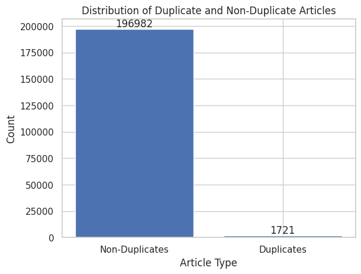

```python
# Check for duplicates based on 'clean_lem_title' and 'clean_lem_text'.
duplicates = news_rel[['clean_lem_title', 'clean_lem_text']].duplicated()
duplicate_count = duplicates.value_counts()

# Create DataFrames with non-duplicate and duplicate articles.
non_duplicates_df = news_rel[~duplicates].copy()
duplicates_df = news_rel[duplicates].copy()

# Reset the DataFrame index for the new DataFrames.
non_duplicates_df.reset_index(drop=True, inplace=True)
duplicates_df.reset_index(drop=True, inplace=True)

# Plot the bar chart to visualize the distribution of duplicates and non-duplicates.
plt.bar(['Non-Duplicates', 'Duplicates'], duplicate_count)
plt.xlabel('Article Type')
plt.ylabel('Count')
plt.title('Distribution of Duplicate and Non-Duplicate Articles')

# Annotate the bars with their corresponding counts.
for i, count in enumerate(duplicate_count):
    plt.text(i, count, str(count), ha='center', va='bottom')
plt.show()
```

```python
duplicates = non_duplicates_df['clean_lem_text'].duplicated()
duplicate_count = duplicates.value_counts()
print(duplicate_count)

non_duplicates_df = non_duplicates_df[~duplicates].copy()
non_duplicates_df.shape
```

```
False    196981
True          1
Name: clean_lem_text, dtype: int64
```

```
(196981, 7)
```

```python
non_duplicates_df.to_parquet('basic_cleaned_rel_non_duplicate_data.parquet')

bucket_name = 'nlp_final_ss'
file_path = 'basic_cleaned_rel_non_duplicate_data.parquet'

storage_client = storage.Client()
bucket = storage_client.get_bucket(bucket_name)
blob = bucket.blob(file_path)
blob.upload_from_filename(file_path)
```

## Finding lengths and visualizing the distribution on text and title column

```python
non_duplicates_df = pd.read_parquet('gs://nlp_final_ss/basic_cleaned_rel_non_duplicate_data.parquet')
non_duplicates_df.shape
```

```
(196981, 7)
```

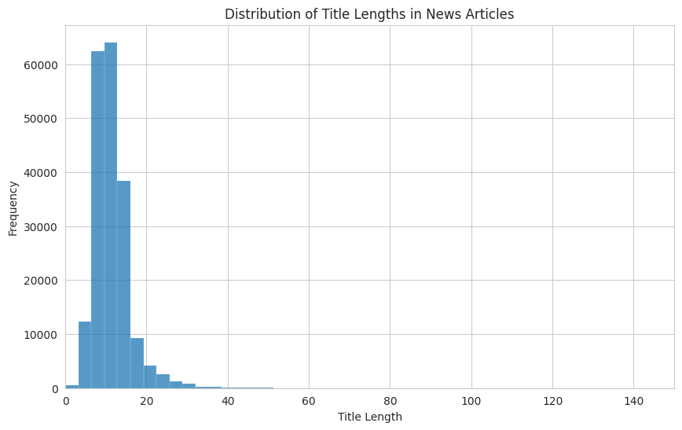

```python
# Calculate the title length for each news article.
non_duplicates_df['title_length'] = non_duplicates_df['clean_lem_title'].parallel_apply(lambda x : len(x.split()))

# Plot a histogram to visualize the distribution of text lengths.
plt.figure(figsize=(10, 6))
sns.histplot(data=non_duplicates_df,bins = 500,  x='title_length')
plt.xlabel('Title Length')
plt.ylabel('Frequency')
plt.title('Distribution of Title Lengths in News Articles')
plt.xlim(0, 150)
plt.show()
```

[output not shown]

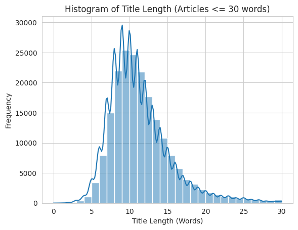

```python
# Filter the DataFrame to include articles with a maximum length of 30 words.
print(non_duplicates_df[(non_duplicates_df.title_length <= 30)].shape)
filtered_title = non_duplicates_df[(non_duplicates_df.title_length <= 30)]

# Plot a histogram of the 'title_length' column for the filtered articles.
sns.histplot(data=filtered_title, bins = 30, x='title_length', kde = True)
plt.xlabel('Title Length (Words)')
plt.ylabel('Frequency')
plt.title('Histogram of Title Length (Articles <= 30 words)')
plt.show()
```

```
(195736, 9)
```

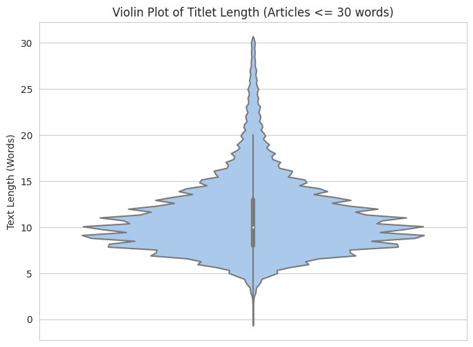

```python
# Filter the DataFrame to include articles with a maximum length of 2000 words.
filtered_title = non_duplicates_df[(non_duplicates_df.title_length <= 30)]
print(filtered_title.shape)

# Set the style
sns.set_style("whitegrid")

# Create a violin plot of the 'title_length' column for the filtered articles.
plt.figure(figsize=(8, 6))
sns.violinplot(data=filtered_title, y='title_length', palette='pastel')
plt.ylabel('Text Length (Words)')
plt.title('Violin Plot of Titlet Length (Articles <= 30 words)')
plt.show()
```

```python
non_duplicates_df["title_length"].describe(percentiles=[0.05,0.1, 0.5, 0.75, 0.8,0.9,0.95])
```

```
count    196981.000000
mean         11.397490
std           7.596781
min           0.000000
5%            6.000000
10%           7.000000
50%          10.000000
75%          13.000000
80%          14.000000
90%          16.000000
95%          20.000000
max        1603.000000
Name: title_length, dtype: float64
```

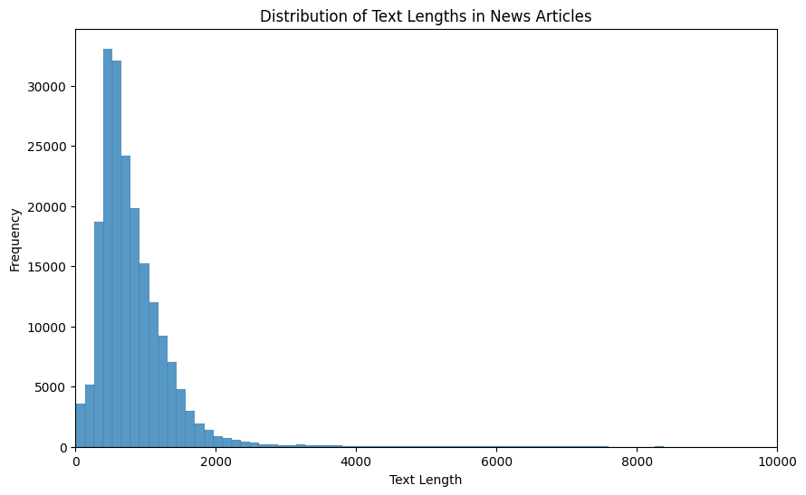

```python
# Calculate the text length for each news article.
non_duplicates_df['text_length'] = non_duplicates_df['clean_lem_text'].parallel_apply(lambda x : len(x.split()))

# Plot a histogram to visualize the distribution of text lengths.
plt.figure(figsize=(10, 6))
sns.histplot(data=non_duplicates_df,bins = 1000,  x='text_length')
plt.xlabel('Text Length')
plt.ylabel('Frequency')
plt.title('Distribution of Text Lengths in News Articles')
plt.xlim(0, 10000)
plt.show()
```